# Instalar Cookiecutter

[figure not shown]

## ¿Qué es Cookiecutter?

Es un manejador de plantillas multiplataforma (Windows, Mac OS, Linux) que te permite hacer plantillas en lenguaje de programación (Python,Julia, R) o lenguaje de marcado (Markdown). Puede ser usado como herramienta de línea de comandos o como librería de Python.

## [¿Cómo funciona?](https://cookiecutter.readthedocs.io/en/1.7.2/README.html)

[figure not shown]

[Cookiecutter](https://cookiecutter-data-science.drivendata.org/) funciona con Jinja, un motor de plantillas extensible con el cual puedes crear plantillas como si estuvieras escribiendo código en Python.

[figure not shown]

Hay 3 pasos para entender la manera en que funciona:

1. Detectará una sintaxis especial en los documentos y carpetas de tu proyecto.
2. Buscará variables y valores a reemplazar.
3. Finalmente, entregará un proyecto con la estructura definida en la plantilla.

## Sintaxis de Jinja

Existen 3 tipos diferentes de bloques:

1. Bloques de expresión: se usan para incluir variables en la plantilla:  
   `{{ cookiecutter.saluda }}`
2. Bloques de declaración: se usan para el uso de condicionales, ciclos, etc.:  
   `{% if coockiecutter.eres_asombroso %}`  
   `...`  
   `{% endif %}`
3. Bloques de comentario: se usan para dejar comentarios o recomendaciones a los propios desarrolladores:  
   `{# Esto es un comentario (Recomendaciones para quien lea la plantilla) #}`

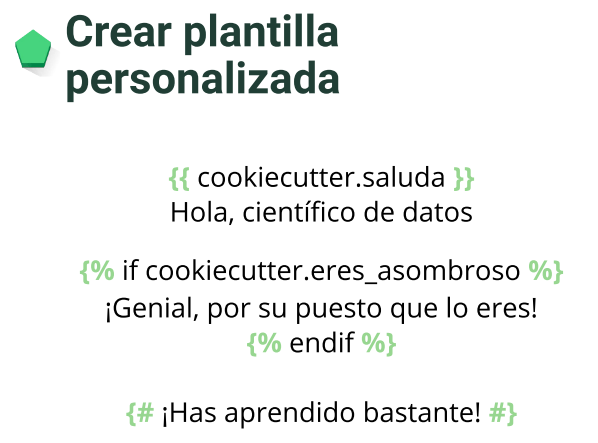

## Instalación de Cookiecutter

**Importante:** Todos los pasos son vía consola y con Anaconda instalado.

### Crea una carpeta un entrar en ella:

```
#Estando en /Configuracion_profesional_Entorno/codes
#Creamos una carpeta
mkdir cookiecutter-personal
cd cookiecutter-personal
```

## Instalando Cookiecutter:

### Agrega el canal Conda-Forge a tu configuración global:

```
#Cookiecutter se encuentra solo en este canal
#por eso primero agregamos el canal
conda config --add channels conda-forge
```

### Crea un ambiente virtual que contenga a Coockiecutter:

```
#Podemos llamarlo env, para que sigamos la convención
#de agregar a un repositorio con gitignore
conda create --name env cookiecutter=1.7.3
#o cookiecutter
conda create --name cookiecutter cookiecutter=1.7.3
```

Con este comando conda empezara a descargar e instalar paquetes a mi entorno virtual para utilizar cookie cutter.

### Activa el ambiente virtual:

```
#escogimos el nombre de env
conda activate env
```

### Definir en dónde estará tu ambiente:

```
#Para exportar las configuraciones de un ambiente
conda env export --from-history --file environment.yml
```

### Para desactivar el ambiente virtual:

```
conda deactivate
```

Contribución creada por: Néstor Arellano.

Entonces lo anterior nos crea un ambiente y un archivo en el cual podemos replicar el ambiente.

Procederemos a copiar una plantilla desde el repositorio de Platzi.

Con la siguiente linea de comando:

```
cookiecutter https://github.com/platzi/curso-entorno-avanzado-ds --checkout cookiecutter-personal-platzi
```

Después te dirá que nombre del proyecto quieres.  
Después creara un `slug` con minúsculas y guiones bajos. Enter, y luego te pide el nombre de compañía o Team, después pide e-mail, pero si no queremos lo dejamos en blanco, después por ultimo pide la descripción del proyecto.

Luego nos pide si queremos instalar todos los paquetes o lo mínimo. Pide la versión de Python y la versión de proyecto.

[figure not shown]

### Abriendo la Plantilla

si ingresamos el siguiente comando, me abre la plantilla en visual studio code.

```
code cookiecutter_testing/
```

Me abre todo el árbol del proyecto

[figure not shown]

Y ya me crea todo lo necesario del proyecto.

Es decir esta es la magia de las plantillas, solo le das unos cuantos parámetros y crea entornos, arboles de carpetas, ademas de un repositorio em git del proyecto.

Así podemos utilizar las plantillas, e instalar cookiecutter. Además creamos un proyecto a partir de una plantilla que ya estaba definida.